# Exploratory Image Analysis

### Problem Statement

For this problem, given a group selfie/photo, we are required to count the number of heads present in the picture. The primary aim of face detection algorithms is to determine whether there is any face in an image or not.

- *To develop an initial answer to your question*  
  The method of face detection in pictures is complicated because of variability present across human faces such as pose, expression, position and orientation, skin colour, the presence of glasses or facial hair, differences in camera gain, lighting conditions, and image resolution. However, recent advancements in field has made the objects detection feasible using deep learning. We are going to use available open source libraries to implement this project.
- *To determine whether the question you are asking can be answered by the data you have collected*  
  The above problem can be addressed using Deep Learning. We have collected adequate data to develop a model and produce the predictions of the face counts in a given image.
- *To determine if there are any problems with your dataset*  
  There is no problem with dataset or the images gathered to perfrom the tasks. Below is the basic exploratory image analysis.

### Exploratory Image Analysis

Packages used to perfrom the analysis

```python
import numpy as mnp
import matplotlib.pyplot as plt
import pandas as pd
import seaborn as sns
import cv2
import os
import warnings
warnings.filterwarnings('ignore')
%matplotlib inline
```

#### Basic description of the data set

The Image dataset contains the 8,196 images and bifircated into train and test datasets. Below is the short summary of the training dataset. The training dataset contains 5733 images and "HeadCount" happens to be the target variable i.e., the number of faces identified in the given image.

```python
df = pd.read_csv("E:\\Face_Count\\train_HNzkrPW (1)\\train.csv")
print("Shape of the dataset:", df.shape)
print("Head: ")
print(df.head())
print("Tail: ")
print(df.tail())
```

```
Shape of the dataset: (5733, 2)
Head:
        Name  HeadCount
0  10001.jpg          4
1  10002.jpg          4
2  10003.jpg          2
3  10004.jpg          3
4  10006.jpg          4
Tail:
           Name  HeadCount
5728  18201.jpg          2
5729  18203.jpg          3
5730  18204.jpg          5
5731  18205.jpg          8
5732  18207.jpg          4
```

#### Basic Exploration

Inspecting the dimensions of the images in the training dataset. Mostly, the images have the similar shape. Further we will explore the images in detail.

```python
# First 5 images shape.
print("Head: ")
for i in os.listdir("E:\\Face_Count\\train_HNzkrPW (1)\\train_images\\train")[:5]:
    image = plt.imread("E:\\Face_Count\\train_HNzkrPW (1)\\train_images\\train\\"+i)
    print(image.shape)
print("Tail: ")
# Last 5 images shape.
for i in os.listdir("E:\\Face_Count\\train_HNzkrPW (1)\\train_images\\train")[-5:]:
    image = plt.imread("E:\\Face_Count\\train_HNzkrPW (1)\\train_images\\train\\"+i)
    print(image.shape)
```

```
Head:
(408, 612, 3)
(408, 612, 3)
(383, 612, 3)
(407, 612, 3)
(408, 612, 3)
Tail:
(407, 612, 3)
(408, 612, 3)
(430, 612, 3)
(425, 612, 3)
(612, 475, 3)
```

Randomly two images are selected for the analysis and below shows the maximum and minimum values of the pixles in the given image.

```python
first = plt.imread("E:\\Face_Count\\train_HNzkrPW (1)\\train_images\\train\\10436.jpg")
print("Shape of the Image: ",first.shape)
print("Maximum Pixel Density: ",first.max())
print("Minimum Pixel Density: ",first.min())
```

```
Shape of the Image:  (408, 612, 3)
Maximum Pixel Density:  255
Minimum Pixel Density:  0
```

```python
second = plt.imread("E:\\Face_Count\\train_HNzkrPW (1)\\train_images\\train\\10437.jpg")
print(second.shape)
print(second.max())
print(second.min())
```

```
(408, 612, 3)
255
0
```

For any image specific classification, clustering, etc. transforms we'll want to collapse spatial dimensions so that we have a matrix of pixels by color channels.

```python
pixel_matrix1 = np.reshape(first, (first.shape[0] * first.shape[1], first.shape[2]))
print(pixel_matrix1.shape)
pixel_matrix2 = np.reshape(second, (second.shape[0] * second.shape[1], second.shape[2]))
print(pixel_matrix2.shape)
```

```
(249696, 3)
(249696, 3)
```

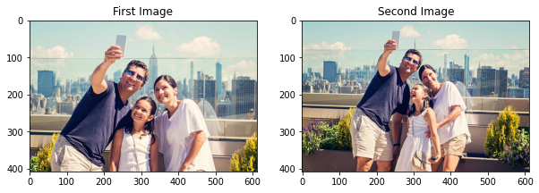

```python
plt.figure(figsize=(10,10))
plt.subplot(121)
plt.title("First Image")
plt.imshow(first)
plt.subplot(122)
plt.title("Second Image")
plt.imshow(second)
plt.show()
```

Image scatter plots are used to examine the assocation between image bands and thier relationship to features and material of interest.We used 2D histogram to reveal the density well and data between bands are highly correlated.

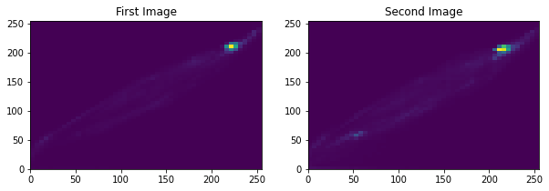

```python
plt.figure(figsize=(10,3))
plt.subplot(121)
_ = plt.hist2d(pixel_matrix1[:,1], pixel_matrix1[:,2], bins = (50,50))
plt.title("First Image")
plt.subplot(122)
_ = plt.hist2d(pixel_matrix2[:,1], pixel_matrix2[:,2], bins = (50,50))
plt.title("Second Image")
plt.show()
```

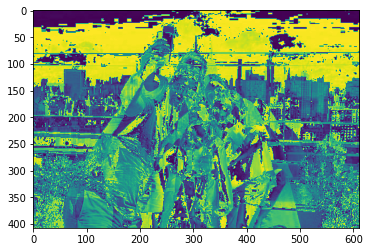

```python
plt.imshow(first[:, :, 2] - second[:, :, 1])
plt.show()
```

A quick loot at color value histogram for pixel matrix from first image

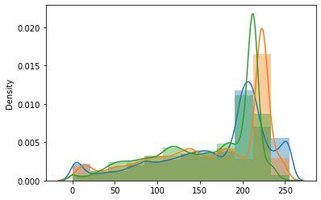

```python
sns.distplot(pixel_matrix1[:,0], bins = 12)
sns.distplot(pixel_matrix1[:,1], bins = 12)
sns.distplot(pixel_matrix1[:,2], bins = 12)
plt.show()
```

### Simple Thresholding

Here, we are going to use OpenCV library mainly aimed at real-time computer vision. Thresholding is a very popular segmentation technique, used for separating an object considered as a foreground from its background. A threshold is a value which has two regions on its either side i.e. below the threshold or above the threshold.  
The function cv2.threshold is used to apply the thresholding. The first argument is the source image, which should be a **grayscale image**. The second argument is the threshold value which is used to classify the pixel values. The third argument is the maximum value which is assigned to pixel values exceeding the threshold. OpenCV provides different types of thresholding which is given by the fourth parameter of the function. Below are the differnt types of thresholdings.

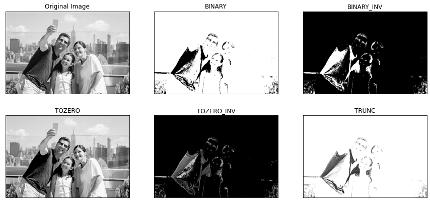

```python
first_cv = cv2.imread("E:\\Face_Count\\train_HNzkrPW (1)\\train\\10436.jpg",0)
#first_cv = cv2.cvtColor(first_cv, cv2.COLOR_BGR2RGB)
_, th1 = cv2.threshold(first_cv, 50, 255, cv2.THRESH_BINARY)
_, th2 = cv2.threshold(first_cv, 50, 255, cv2.THRESH_BINARY_INV)
_, th3 = cv2.threshold(first_cv, 50, 255, cv2.THRESH_TOZERO)
_, th4 = cv2.threshold(first_cv, 50, 255, cv2.THRESH_TOZERO_INV)
_, th5 = cv2.threshold(first_cv, 50, 255, cv2.THRESH_TRUNC)
titles = ["Original Image", "BINARY", "BINARY_INV", "TOZERO", "TOZERO_INV", "TRUNC"]
images = [first_cv, th1, th2, th3, th4, th5]
plt.figure(figsize= (15,7))
for i in range(6):
    plt.subplot(2,3,i+1), plt.imshow(images[i], 'gray')
    plt.title(titles[i])
    plt.xticks([]), plt.yticks([])
plt.show()
```

Another Thresholding technique is **Adaptive Thresholding**. Simple Thresholding, a global value of threshold was used which remained constant throughout. So, a constant threshold value won’t help in the case of variable lighting conditions in different areas. Adaptive thresholding is the method where the threshold value is calculated for smaller regions. This leads to different threshold values for different regions with respect to the change in lighting.

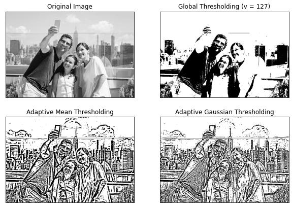

```python
_, th1 = cv2.threshold(first_cv, 127, 255, cv2.THRESH_BINARY)
th2 = cv2.adaptiveThreshold(first_cv, 255, cv2.ADAPTIVE_THRESH_MEAN_C, \
                               cv2.THRESH_BINARY, 11, 2)
th3 = cv2.adaptiveThreshold(first_cv, 255, cv2.ADAPTIVE_THRESH_GAUSSIAN_C,\
                                cv2.THRESH_BINARY, 11, 2)
titles = ['Original Image', 'Global Thresholding (v = 127)',
            'Adaptive Mean Thresholding', 'Adaptive Gaussian Thresholding']
images = [first_cv, th1, th2, th3]
plt.figure(figsize= (10,7))
for i in range(4):
    plt.subplot(2,2,i+1),plt.imshow(images[i],'gray')
    plt.title(titles[i])
    plt.xticks([]),plt.yticks([])
plt.show()
```

In **Otsu Thresholding**, a value of the threshold isn’t chosen but is determined automatically. A bimodal image (two distinct image values) is considered. The histogram generated contains two peaks. So, a generic condition would be to choose a threshold value that lies in the middle of both the histogram peak values

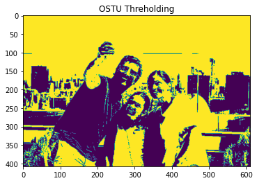

```python
ret2,th2 = cv2.threshold(first_cv,0,255,cv2.THRESH_BINARY+cv2.THRESH_OTSU)
plt.imshow(th2)
plt.title("OSTU Threholding")
plt.show()
```

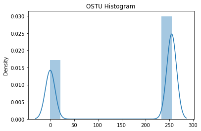

```python
sns.distplot(th2, bins = 12)
plt.title("OSTU Histogram")
plt.show()
```

**Histogram equalization** is a method in image processing of contrast adjustment using the image’s histogram. This method usually increases the global contrast of many images, especially when the usable data of the image is represented by close contrast values. Through this adjustment, the intensities can be better distributed on the histogram. This allows for areas of lower local contrast to gain a higher contrast.

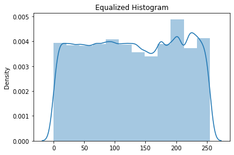

```python
sns.distplot(cv2.equalizeHist(first_cv), bins = 12)
plt.title("Equalized Histogram")
plt.show()
```

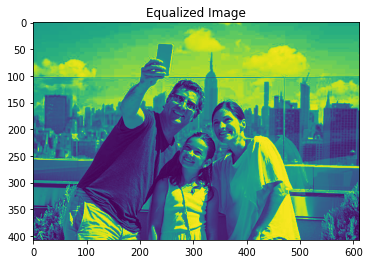

```python
plt.imshow(cv2.equalizeHist(first_cv))
plt.title("Equalized Image")
plt.show()
```

### Edge Detection

[figure not shown]

```python
canny = cv2.Canny(first_cv, 100, 200)
sobelx = cv2.Sobel(first_cv, cv2.CV_64F, 1, 0)
sobely = cv2.Sobel(first_cv, cv2.CV_64F, 0, 1)
SobelCombined = cv2.bitwise_and(sobelx, sobely)
lap = cv2.Laplacian(first_cv, cv2.CV_64F, ksize = 3)
lap = np.uint8(np.absolute(lap))
titles = ["Original Image", "Canny", "Sobel", "Laplacian"]
images = [first_cv, canny, SobelCombined, lap]
plt.figure(figsize=(10,8))
for i in  range(4):
    plt.subplot(2, 2, i+1), plt.imshow(images[i], 'gray')
    plt.title(titles[i])
    plt.xticks([]), plt.yticks([])
plt.show()
```

This project is basically a computer vision task that *deep learning* will be a good fit. The above analysis is made using *Matplotlib* and *OpenCV* packages. The actual implementation of the project i.e., the face detection and counting will be implemented in *Keras* and *TensorFlow* powered by GPU enabled AWS virtual machine or Google Collab.